# Model checking as model *building*: length of stay in the RHC/SUPPORT study

## 7. Epilog: use Poisson instead of log-OLS

**Question**

All the retransformation fuss in section 3 exists only because we logged the **outcome**. Is there a model that gives **mean days directly**, with no smearing factor?

**Hint**

Poisson regression puts the log on the **link**, modeling `E(LOS|X) = exp(Xβ)` on the day scale. With `vce(robust)` the Poisson pseudo-MLE is consistent for that mean even though LOS is not a count and is over-dispersed (Gould 2011; Silva & Tenreyro 2006).

**Answer**

```stata
poisson los i.cat1 c.surv2md1##c.surv2md1 i.dnr1 c.age i.sex, vce(robust)
margins cat1
marginsplot, horizontal recast(scatter) ///
    title("Poisson: predicted mean LOS by disease category") ///
    xtitle("Predicted LOS (days)")
qui graph export img/rhc_pois_cat.png, replace width(1400)
```

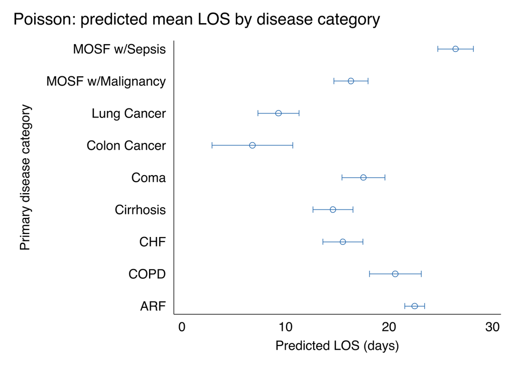

Predicted mean LOS by disease category from the robust Poisson model, on the day scale with no retransformation.

Side-by-side, the two methods for getting a mean on the day scale — log-OLS + Duan smearing, and Poisson with robust SEs — reach a similar place:

```stata
quietly regress lnlos i.cat1 c.surv2md1##c.surv2md1 i.dnr1 c.age i.sex
capture drop er2 eer2
predict double er2, residuals
generate double eer2 = exp(er2)
summarize eer2, meanonly
scalar duan2 = r(mean)
quietly margins cat1, expression(duan2*exp(xb())) post
estimates store logols_duan
quietly poisson los i.cat1 c.surv2md1##c.surv2md1 i.dnr1 c.age i.sex, vce(robust)
quietly margins cat1, post
estimates store poisson_mean
estimates table logols_duan poisson_mean, b(%6.2f) se ///
    title("Predicted mean LOS by disease category: log-OLS+Duan vs Poisson")
```

```
Predicted mean LOS by disease category: log-OLS+Duan vs Poisson

----------------------------------
    Variable | logol~n   poiss~n
-------------+--------------------
        cat1 |
        ARF  |   22.76     22.47
             |    0.40      0.49
       COPD  |   20.82     20.60
             |    0.93      1.28
        CHF  |   15.54     15.54
             |    0.74      0.99
  Cirrhosis  |   15.94     14.58
             |    0.94      0.99
       Coma  |   16.56     17.53
             |    0.76      1.05
Colon Can..  |    8.76      6.80
             |    2.91      2.00
Lung Cancer  |   11.38      9.32
             |    1.60      1.01
MOSF w/Ma..  |   18.06     16.32
             |    0.88      0.84
MOSF w/Se..  |   24.99     26.42
             |    0.63      0.88
----------------------------------
                      Legend: b/se
```

The Poisson route needs no retransformation and carries its own robust standard errors — so for a skewed, positive outcome like LOS, you can *use `poisson` rather than `regress`.*

## Recap:

In the end, we did not check the model to certify it afterword; we checked it as part of building it. In order of consequence:

- **Outcome scale** (sections 1, 2, 5): a naive normal-error model on raw days predicts impossible negative stays and is miscalibrated. Logging fixes both.
- **A hidden mixture** (sections 2, 4): the inverted-U in predicted survival is survivors and deaths running in opposite directions — you can describe them separately, but do not “adjust” for a downstream collider.
- **Confounding by design** (section 6, endogeneity): this problem can not be identifed in model checking it has to be argued
- **Standard-error assumptions** (section 6): independence, homoskedasticity, normality — the *least* consequential, and largely handled by the log scale, cluster or robust SEs, and a large enough sample.